# Welcome to the tidyverse

### Plot lines

Depending on what we want to plot, we can change the geometry `geom` object we use. If we want a smoothed line plot, we could use `geom_smooth`:

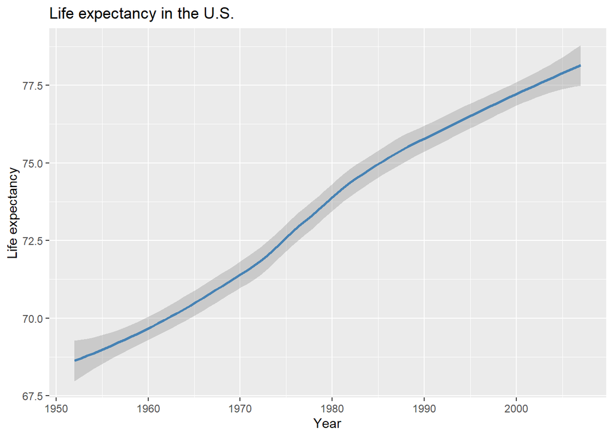

```r
ggplot(data=us) +
  geom_smooth(mapping = aes(x = year, y = lifeExp), color = "steelblue") +
  ggtitle("Life expectancy in the U.S.") +
  xlab("Year") +
  ylab("Life expectancy")
```

Another cool trick is that we can pipe `%>%` our `dplyr` manipulations straight into a `ggplot()`. (Don’t do this if you have a bunch of steps.) Let’s make a life expectancy plot for Sierra Leone using this approach:

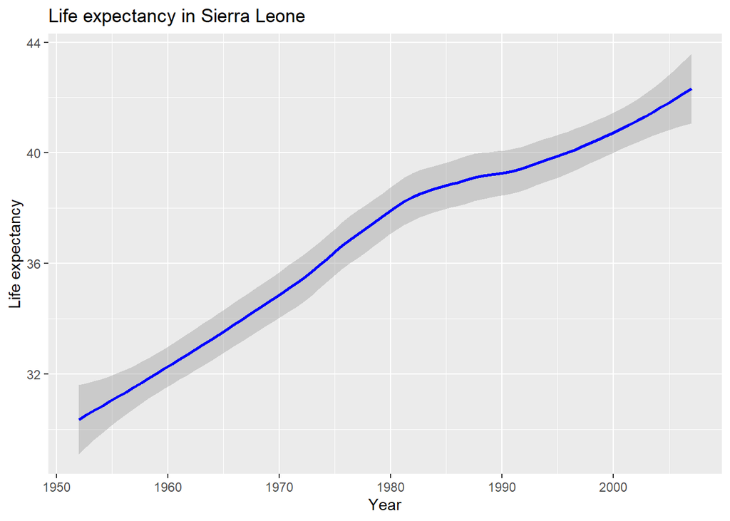

```r
gapminder %>%
  filter(country == "Sierra Leone") %>%
  ggplot() +
    geom_smooth(mapping = aes(x = year, y = lifeExp), color = "blue") +
    ggtitle("Life expectancy in Sierra Leone") +
    xlab("Year") +
    ylab("Life expectancy")
```

Notice the use of *indentation* and *line breaks*? Keep your code tidy.

What if we wanted to compare life expectancy in the United States with life expectancy in Sierra Leone in a single plot?

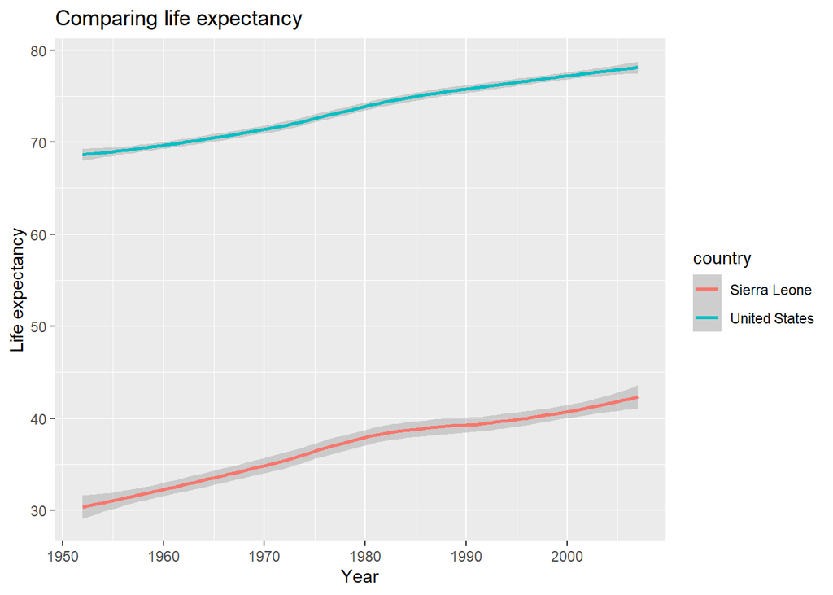

```r
gapminder %>%
  filter(country %in% c("Sierra Leone", "United States")) %>%
  ggplot() +
    geom_smooth(mapping = aes(x = year, y = lifeExp, color = country)) +
    ggtitle("Comparing life expectancy") +
    xlab("Year") +
    ylab("Life expectancy")
```

If you want to filter using multiple criteria, use `%in%` rather than `==`. This selects all rows with `country` equal to the countries in the list we created using `c()`.

Since our dataframe contains information from two countries, we can add an argument to the `geom_smooth()` function that tells `ggplot()` to group observations by country and to symbolize them using two different colors. We do this by adding the argument `color=country`.